# Project: TMDb Movie Data

- Introduction
- Data Wrangling
- Exploratory Data Analysis
- Conclusions

## Introduction

> In this project we'll be analyzing a movies dataset from Kaggle which contains basic information provided by The Movie Database (TMDb) about movies, its popularity, budget, revenue amongst others spanning from 1960 to 2015. After data preparation, the characteristics of movies are investigated in respect to the **revenue**, **popularity**, **runtime** and **vote_average**.

### Dataset Description

> This dataset contains information about 10,000 movies collected from The Movie Database (TMDb). It contains twenty-one (21) columns and below are the descriptions for each column.

#### Column Description:

> **`id`** **`imdb_id`** : unique id or imdb for each movie on TMDB.  
> **`popularity`** : this measures how popular the movie is.  
> **`budget`** : the total budget of the movie in USD.  
> **`revenue`** : total revenue of the movie in USD.  
> **`original_title`** : the title of the movie.  
> **`cast`** : names of the cast of the movie separated by "|".  
> **`homepage`** : the website of the movie.  
> **`director`** : the name of the director(s) of the movie, it's also separated by "|" when more than 1.  
> **`tagline`** : a catchphrase describing the movie.  
> **`keywords`** : keywords related to the movie.  
> **`overview`** : summary of the plot of the movie.  
> **`runtime`** : total runtime of the movie in minutes.  
> **`genre`** : genres of the movie separated by "|".  
> **`production_companies`** : production company/companies of the movie.  
> **`release_date`** : release date of the movie.  
> **`vote_count`** : number of voters of the movie.  
> **`vote_average`** : average user rating of the movie.  
> **`release_year`** : release year of the movie ranging from 1960 to 2015.  
> **`budget_adj`** : the total budget of the movie in USD in terms of 2010 dollars (accounting for inlation over time).  
> **`revenue_adj`** : the total revenue of the movie in USD in terms of 2010 dollars (accounting for inlation over time).

### Question(s) for Analysis

#### 1. What genres are the most popular? What is the popularity trend by year?

#### 2. Do movies with longer duration have higher rating than the short ones?

#### 3. What features are associated with generating higher revenues?

### Importing the necessary packages

#### The following libraries were imported

- **Pandas** for data wrangling, cleaning and exploration.
- **NumPy** for numerical and mathematical computations.
- **Matplotlib** for creating interactive visualizations.
- **Seaborn** to improve the quality of the visualiztions.
- **%matplotlib inline** magic function to enable inline plotting.

```python
import pandas as pd
import numpy as np
import matplotlib.pyplot as plt
import seaborn as sns
%matplotlib inline
```

## Data Wrangling

> Here we'll be loading our data and checking for its general properties to get a better understanding of the data. To do this, we'll be checking for the:
> - shape of the data
> - data type of the columns
> - columns containing missing values
> - descriptive statistics of the columns

Loading the csv file of the dataset and checking for its characteristics:

```python
df = pd.read_csv('tmdb-movies.csv')
```

```python
# Checking for the first 5 rows of the dataset

df.head()
```

|  | id | imdb_id | popularity | budget | revenue | original_title | cast | homepage | director | tagline | ... | overview | runtime | genres | production_companies | release_date | vote_count | vote_average | release_year | budget_adj | revenue_adj |
| --- | --- | --- | --- | --- | --- | --- | --- | --- | --- | --- | --- | --- | --- | --- | --- | --- | --- | --- | --- | --- | --- |
| 0 | 135397 | tt0369610 | 32.985763 | 150000000 | 1513528810 | Jurassic World | Chris Pratt\|Bryce Dallas Howard\|Irrfan Khan\|Vi... | http://www.jurassicworld.com/ | Colin Trevorrow | The park is open. | ... | Twenty-two years after the events of Jurassic ... | 124 | Action\|Adventure\|Science Fiction\|Thriller | Universal Studios\|Amblin Entertainment\|Legenda... | 6/9/15 | 5562 | 6.5 | 2015 | 1.379999e+08 | 1.392446e+09 |
| 1 | 76341 | tt1392190 | 28.419936 | 150000000 | 378436354 | Mad Max: Fury Road | Tom Hardy\|Charlize Theron\|Hugh Keays-Byrne\|Nic... | http://www.madmaxmovie.com/ | George Miller | What a Lovely Day. | ... | An apocalyptic story set in the furthest reach... | 120 | Action\|Adventure\|Science Fiction\|Thriller | Village Roadshow Pictures\|Kennedy Miller Produ... | 5/13/15 | 6185 | 7.1 | 2015 | 1.379999e+08 | 3.481613e+08 |
| 2 | 262500 | tt2908446 | 13.112507 | 110000000 | 295238201 | Insurgent | Shailene Woodley\|Theo James\|Kate Winslet\|Ansel... | http://www.thedivergentseries.movie/#insurgent | Robert Schwentke | One Choice Can Destroy You | ... | Beatrice Prior must confront her inner demons ... | 119 | Adventure\|Science Fiction\|Thriller | Summit Entertainment\|Mandeville Films\|Red Wago... | 3/18/15 | 2480 | 6.3 | 2015 | 1.012000e+08 | 2.716190e+08 |
| 3 | 140607 | tt2488496 | 11.173104 | 200000000 | 2068178225 | Star Wars: The Force Awakens | Harrison Ford\|Mark Hamill\|Carrie Fisher\|Adam D... | http://www.starwars.com/films/star-wars-episod... | J.J. Abrams | Every generation has a story. | ... | Thirty years after defeating the Galactic Empi... | 136 | Action\|Adventure\|Science Fiction\|Fantasy | Lucasfilm\|Truenorth Productions\|Bad Robot | 12/15/15 | 5292 | 7.5 | 2015 | 1.839999e+08 | 1.902723e+09 |
| 4 | 168259 | tt2820852 | 9.335014 | 190000000 | 1506249360 | Furious 7 | Vin Diesel\|Paul Walker\|Jason Statham\|Michelle ... | http://www.furious7.com/ | James Wan | Vengeance Hits Home | ... | Deckard Shaw seeks revenge against Dominic Tor... | 137 | Action\|Crime\|Thriller | Universal Pictures\|Original Film\|Media Rights ... | 4/1/15 | 2947 | 7.3 | 2015 | 1.747999e+08 | 1.385749e+09 |

5 rows × 21 columns

### General Properties

```python
# Checking for the dimension of the dataframe

df.shape
```

```
(10866, 21)
```

**NB:** *From the above, we can see that the dataframe contains **`10866`** rows and **`21`** columns!*

```python
# checking for the data type of each column

df.dtypes
```

```
id                        int64
imdb_id                  object
popularity              float64
budget                    int64
revenue                   int64
original_title           object
cast                     object
homepage                 object
director                 object
tagline                  object
keywords                 object
overview                 object
runtime                   int64
genres                   object
production_companies     object
release_date             object
vote_count                int64
vote_average            float64
release_year              int64
budget_adj              float64
revenue_adj             float64
dtype: object
```

**NB:** _From this, it was observed that the `release_date` column has a wrong data type._

```python
# Checking for columns that contained missing values.
df.info()
```

```
<class 'pandas.core.frame.DataFrame'>
RangeIndex: 10866 entries, 0 to 10865
Data columns (total 21 columns):
id                      10866 non-null int64
imdb_id                 10856 non-null object
popularity              10866 non-null float64
budget                  10866 non-null int64
revenue                 10866 non-null int64
original_title          10866 non-null object
cast                    10790 non-null object
homepage                2936 non-null object
director                10822 non-null object
tagline                 8042 non-null object
keywords                9373 non-null object
overview                10862 non-null object
runtime                 10866 non-null int64
genres                  10843 non-null object
production_companies    9836 non-null object
release_date            10866 non-null object
vote_count              10866 non-null int64
vote_average            10866 non-null float64
release_year            10866 non-null int64
budget_adj              10866 non-null float64
revenue_adj             10866 non-null float64
dtypes: float64(4), int64(6), object(11)
memory usage: 1.7+ MB
```

```python
# Total number of columns with null values

df.isna().any().sum()
```

```
9
```

**NB:** **9** columns of the dataset contained missing values.

```python
# Checking for the summary statistics of each column

df.describe()
```

|  | id | popularity | budget | revenue | runtime | vote_count | vote_average | release_year | budget_adj | revenue_adj |
| --- | --- | --- | --- | --- | --- | --- | --- | --- | --- | --- |
| count | 10866.000000 | 10866.000000 | 1.086600e+04 | 1.086600e+04 | 10866.000000 | 10866.000000 | 10866.000000 | 10866.000000 | 1.086600e+04 | 1.086600e+04 |
| mean | 66064.177434 | 0.646441 | 1.462570e+07 | 3.982332e+07 | 102.070863 | 217.389748 | 5.974922 | 2001.322658 | 1.755104e+07 | 5.136436e+07 |
| std | 92130.136561 | 1.000185 | 3.091321e+07 | 1.170035e+08 | 31.381405 | 575.619058 | 0.935142 | 12.812941 | 3.430616e+07 | 1.446325e+08 |
| min | 5.000000 | 0.000065 | 0.000000e+00 | 0.000000e+00 | 0.000000 | 10.000000 | 1.500000 | 1960.000000 | 0.000000e+00 | 0.000000e+00 |
| 25% | 10596.250000 | 0.207583 | 0.000000e+00 | 0.000000e+00 | 90.000000 | 17.000000 | 5.400000 | 1995.000000 | 0.000000e+00 | 0.000000e+00 |
| 50% | 20669.000000 | 0.383856 | 0.000000e+00 | 0.000000e+00 | 99.000000 | 38.000000 | 6.000000 | 2006.000000 | 0.000000e+00 | 0.000000e+00 |
| 75% | 75610.000000 | 0.713817 | 1.500000e+07 | 2.400000e+07 | 111.000000 | 145.750000 | 6.600000 | 2011.000000 | 2.085325e+07 | 3.369710e+07 |
| max | 417859.000000 | 32.985763 | 4.250000e+08 | 2.781506e+09 | 900.000000 | 9767.000000 | 9.200000 | 2015.000000 | 4.250000e+08 | 2.827124e+09 |

```python
# Checking for the actual number of zeros in the runtime column

df.query('runtime == 0').shape[0]
```

```
31
```

```python
# Checking for the actual number of zeros in the budget_adj column

df.query('budget_adj == 0').shape[0]
```

```
5696
```

```python
# Checking for the actual number of zeros in the revenue_adj column

df.query('revenue_adj == 0').shape[0]
```

```
6016
```

### Data Cleaning

> Here we'll be checking for:
> - duplicate rows and dropping them.
> - fixing data type of columns in wrong format.
> - dropping the rows in the columns containing zeros.
> - creating new columns.
> - dropping unwanted columns.

**Checking for duplicates in the dataset and dropping them.**

```python
# Number of duplicate columns

sum(df.duplicated())
```

```
1
```

```python
# Dropping the duplicates

df.drop_duplicates(inplace = True)
```

```python
# confirm the new numbers of rows in the dataset and those containing duplicates.

df.shape[0], df.duplicated().sum()
```

```
(10865, 0)
```

#### Fixing the data type of the release_date column

_I noticed the `release_date` column is in a string format. So the data type has to be changed to a date format._

**This can be done using the `to_datetime()` function of the pandas.**

```python
df['release_date'] = pd.to_datetime(df.release_date)
```

#### Dropping the columns with multiple zero values in them.

*From the descriptive statistics we checked earlier, we discovered that at least **50%** of the values in **budget_adj** and **revenue_adj** are zeros while the **runtime** contain **31** zeros!*

- *All the zeros will be dropped.*

```python
# Subsetting the rows that contained zeros for the set of columns

df_zero = df.loc[(df['revenue_adj'] == 0) | (df['budget_adj'] == 0) | (df['runtime'] == 0)]
```

```python
# Dropping them from our data

df.drop(df_zero.index, axis = 0, inplace = True)
```

```python
df.describe()
```

|  | id | popularity | budget | revenue | runtime | vote_count | vote_average | release_year | budget_adj | revenue_adj |
| --- | --- | --- | --- | --- | --- | --- | --- | --- | --- | --- |
| count | 3854.000000 | 3854.000000 | 3.854000e+03 | 3.854000e+03 | 3854.000000 | 3854.000000 | 3854.000000 | 3854.000000 | 3.854000e+03 | 3.854000e+03 |
| mean | 39888.185262 | 1.191554 | 3.720370e+07 | 1.076866e+08 | 109.220291 | 527.720291 | 6.168163 | 2001.261028 | 4.423999e+07 | 1.370647e+08 |
| std | 67222.527399 | 1.475162 | 4.220822e+07 | 1.765393e+08 | 19.922820 | 879.956821 | 0.794920 | 11.282575 | 4.480925e+07 | 2.161114e+08 |
| min | 5.000000 | 0.001117 | 1.000000e+00 | 2.000000e+00 | 15.000000 | 10.000000 | 2.200000 | 1960.000000 | 9.693980e-01 | 2.370705e+00 |
| 25% | 6073.500000 | 0.462368 | 1.000000e+07 | 1.360003e+07 | 95.000000 | 71.000000 | 5.700000 | 1995.000000 | 1.309053e+07 | 1.835735e+07 |
| 50% | 11321.500000 | 0.797511 | 2.400000e+07 | 4.480000e+07 | 106.000000 | 204.000000 | 6.200000 | 2004.000000 | 3.001611e+07 | 6.173068e+07 |
| 75% | 38573.250000 | 1.368324 | 5.000000e+07 | 1.242125e+08 | 119.000000 | 580.000000 | 6.700000 | 2010.000000 | 6.061307e+07 | 1.632577e+08 |
| max | 417859.000000 | 32.985763 | 4.250000e+08 | 2.781506e+09 | 338.000000 | 9767.000000 | 8.400000 | 2015.000000 | 4.250000e+08 | 2.827124e+09 |

- *As seen above, the multiple zeros have been dropped from the specified columns.*

#### **Creating new columns and dropping the unwanted ones from the dataset**

Some of the columns are separated by the `|`, so the first characters will be splitted and taken out to create a new column.  
These includes the **cast**, **director**, and the **genres** columns.</br>

```python
# Creating a function to split and extract the first character.

def split_column(x, y):

    df[x] = df[y].str.split(pat='|', expand = True)[0]
```

```python
# Using the function on the desired columns to create new columns.

split_column('main_cast', 'cast')
split_column('main_director', 'director')
split_column('main_genre', 'genres')
```

**NB:** *Three more columns have been added to our data **main_cast**, **main_director**, and **main_genre**.*

**Then the unwanted columns can be dropped!**

```python
# Dropping the columns from the data

df.drop(columns=['id', 'imdb_id', 'cast', 'director', 'genres','homepage', 'tagline', 'production_companies', 'overview', 'keywords'],
       inplace = True)
```

#### Filling up the columns containing null values

```python
# Checking for he number of null values for each column

df.isna().sum()
```

```
popularity        0
budget            0
revenue           0
original_title    0
runtime           0
release_date      0
vote_count        0
vote_average      0
release_year      0
budget_adj        0
revenue_adj       0
main_cast         4
main_director     1
main_genre        0
dtype: int64
```

_It can be seen that only **main_cast** & **main_director** columns contain null values._

- *The values are not quite much so we'll drop the affected rows.*

```python
# Dropping the rows

df.dropna(inplace=True)
```

```python
df.info()
```

```
<class 'pandas.core.frame.DataFrame'>
Int64Index: 3849 entries, 0 to 10848
Data columns (total 14 columns):
popularity        3849 non-null float64
budget            3849 non-null int64
revenue           3849 non-null int64
original_title    3849 non-null object
runtime           3849 non-null int64
release_date      3849 non-null datetime64[ns]
vote_count        3849 non-null int64
vote_average      3849 non-null float64
release_year      3849 non-null int64
budget_adj        3849 non-null float64
revenue_adj       3849 non-null float64
main_cast         3849 non-null object
main_director     3849 non-null object
main_genre        3849 non-null object
dtypes: datetime64[ns](1), float64(4), int64(5), object(4)
memory usage: 451.1+ KB
```

- *We have successfully cleaned the data and it's ready for exploratory data analysis!*

## Exploratory Data Analysis

> A matrix of scatter plot is used to gain a quick insight into the relationships between the variables.
> - It will display a scatterplot between numerical variables and a histogram for each variable.

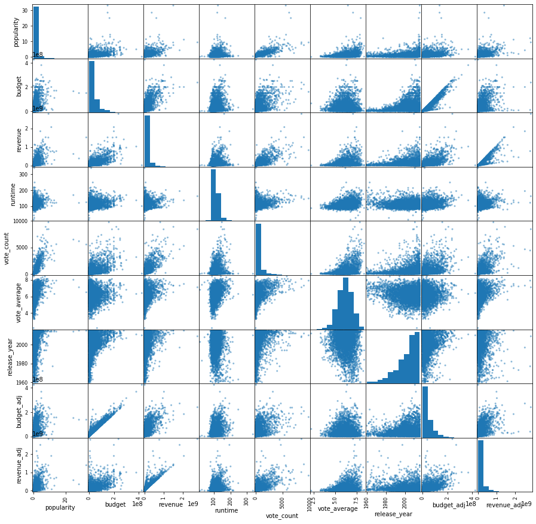

```python
# Scatter plot Matrix

pd.plotting.scatter_matrix(df, figsize=(15,15));
```

**Some basic observation from this scatter plot matrix includes:**

- Most of the columns have a right-skewed distribution, except for the **vote_average** and **release_year** columns.
- **revenue** has positive correlation with the **budget**, **popularity** and **vote_count** columns.
- **revenue** has little or no correlation with **runtime** column.

### Question 1: What genres are the most popular and what is the popularity trend by year?

> We want to find out the movie genre that has been popular the most over the years.  
> We also want to know if movies have generally become more popular than it was in the '60s or not.

```python
# We'll subset the columns of choice into a new dataframe

df_gen = df[['release_year', 'main_genre', 'popularity']]
df_gen.head()
```

|  | release_year | main_genre | popularity |
| --- | --- | --- | --- |
| 0 | 2015 | Action | 32.985763 |
| 1 | 2015 | Action | 28.419936 |
| 2 | 2015 | Adventure | 13.112507 |
| 3 | 2015 | Action | 11.173104 |
| 4 | 2015 | Action | 9.335014 |

```python
# Calculating the popularity mean for each genre in each year

df_mean = df_gen.groupby(['release_year', 'main_genre'], as_index = False)['popularity'].mean()
df_mean.head()
```

|  | release_year | main_genre | popularity |
| --- | --- | --- | --- |
| 0 | 1960 | Action | 1.504538 |
| 1 | 1960 | Comedy | 0.501564 |
| 2 | 1960 | Drama | 2.610362 |
| 3 | 1961 | Action | 0.754548 |
| 4 | 1961 | Adventure | 2.631987 |

```python
# Getting the most popular genre in each year

df_pop = df_mean.groupby('release_year').apply(lambda grp: grp[grp.popularity == grp.popularity.max()]).reset_index(drop=True)
df_pop.head()
```

|  | release_year | main_genre | popularity |
| --- | --- | --- | --- |
| 0 | 1960 | Drama | 2.610362 |
| 1 | 1961 | Adventure | 2.631987 |
| 2 | 1962 | Adventure | 2.169709 |
| 3 | 1963 | Action | 1.357698 |
| 4 | 1964 | Adventure | 3.153791 |

```python
# Counting the number of unique genres that were the most popular through the years

gen_count = df_pop['main_genre'].value_counts()
gen_count
```

```
Adventure          11
Animation          11
Science Fiction     7
Fantasy             6
Romance             4
Family              4
Drama               4
Horror              2
War                 1
Action              1
Western             1
Music               1
Crime               1
History             1
Mystery             1
Name: main_genre, dtype: int64
```

#### Plotting a bar char to show popularity of movies by their genres

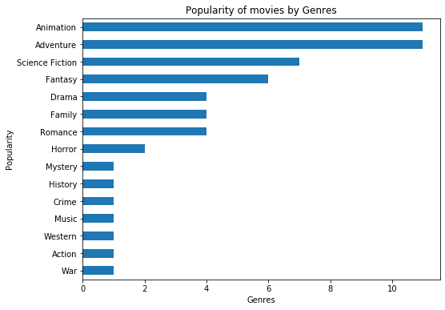

```python
plt.figure(figsize=(8,6))
gen_count.sort_values(ascending=True).plot.barh()
plt.xlabel('Genres')
plt.ylabel('Popularity')
plt.title('Popularity of movies by Genres');
```